# Expressions, Annotations and `phantom()`

Dr Wayne Stewart

2020-05-12

# Introduction

We often need to place annotation on plots and this can become a difficulty because the way in which annotation is typically made is through a series of steps that start with a valid R expression. Annotation will result only if the expressions are valid.

## Example

The following will not work! Why? Because that which is enclosed in the `expression()` must be a valid R expression.

```r
curve(dnorm(x),
      xlim = c(-3,3),
      xlab = expression(-3 <= x <= 3)
)
```

… and `-3 <= x <= 3` is an invalid expression.

The code below works because it contains a valid expression and hence annotation results (see the <= symbol annotated on the plot) – however it is mathematically incorrect for the plot! We might try something else like plot 2 but we lose the high level annotation.

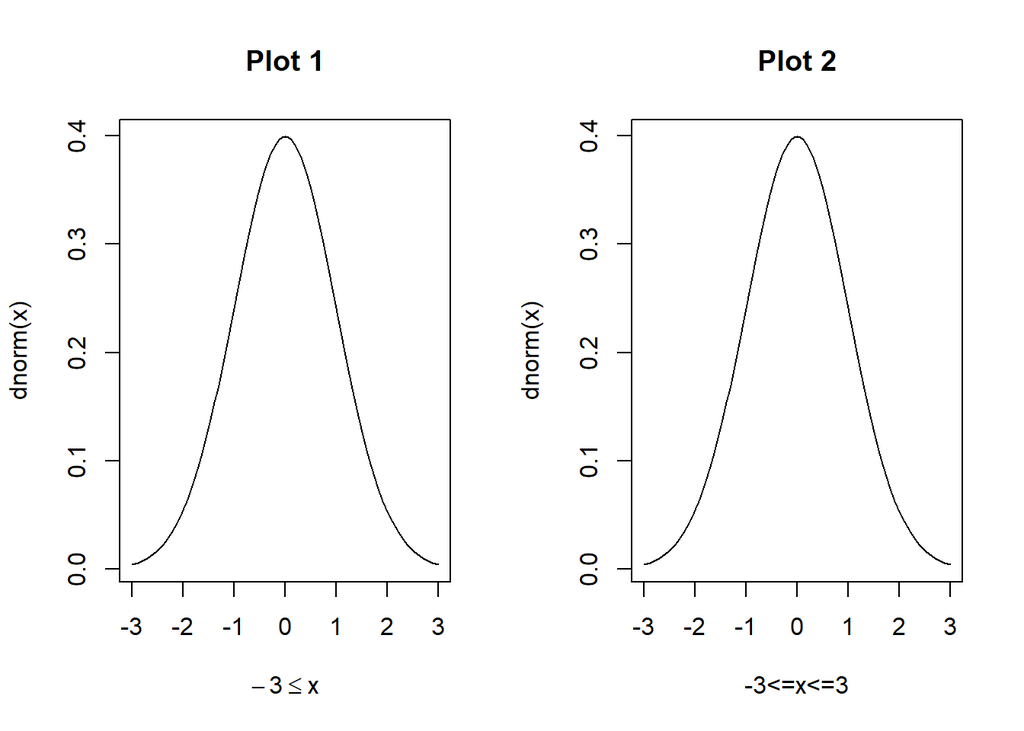

```r
layout(matrix(1:2, nr=1))
curve(dnorm(x),
      xlim = c(-3,3),
      xlab = expression(-3<=x),
      main = "Plot 1"
)

curve(dnorm(x),
      xlim = c(-3,3),
      xlab = "-3<=x<=3",
      main = "Plot 2"
)
```

R documentation for `plotmath` states

> A mathematical expression must obey the normal rules of syntax for any R expression, but it is interpreted according to very different rules than for normal R expressions. It is possible to produce many different mathematical symbols, generate sub- or superscripts, produce fractions, etc.

# One way around this `latex2exp`

Please install the package `latex2exp` and notice the code

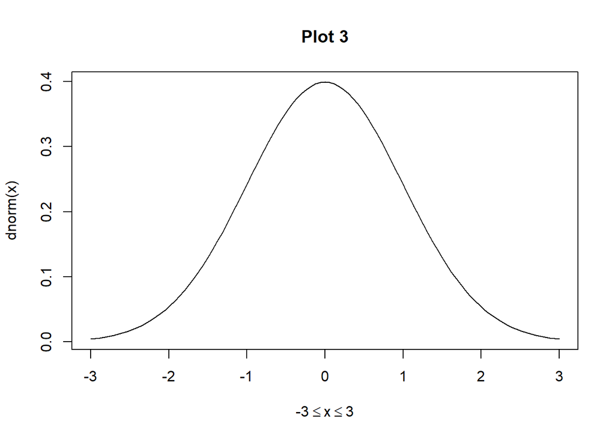

```r
curve(dnorm(x),
      xlim = c(-3,3),
      xlab = TeX('$-3\\leq x \\leq 3$'),
      main = "Plot 3"
)
```

This is really a way of rewriting Latex into the expression - language used by R’s plot annotation.

We can find the expression by using the `TeX` function with `output="expression"`

```r
TeX('$-3\\leq x \\leq 3$',output="expression")
```

```
## expression(`$-3\leq x \leq 3$` = paste("", "-3", phantom() <=
##     phantom(), "x", "", phantom() <= phantom(), "3", ""))
```

# Use of `phantom()`

The above package reminds us of how to use the function `phantom()`

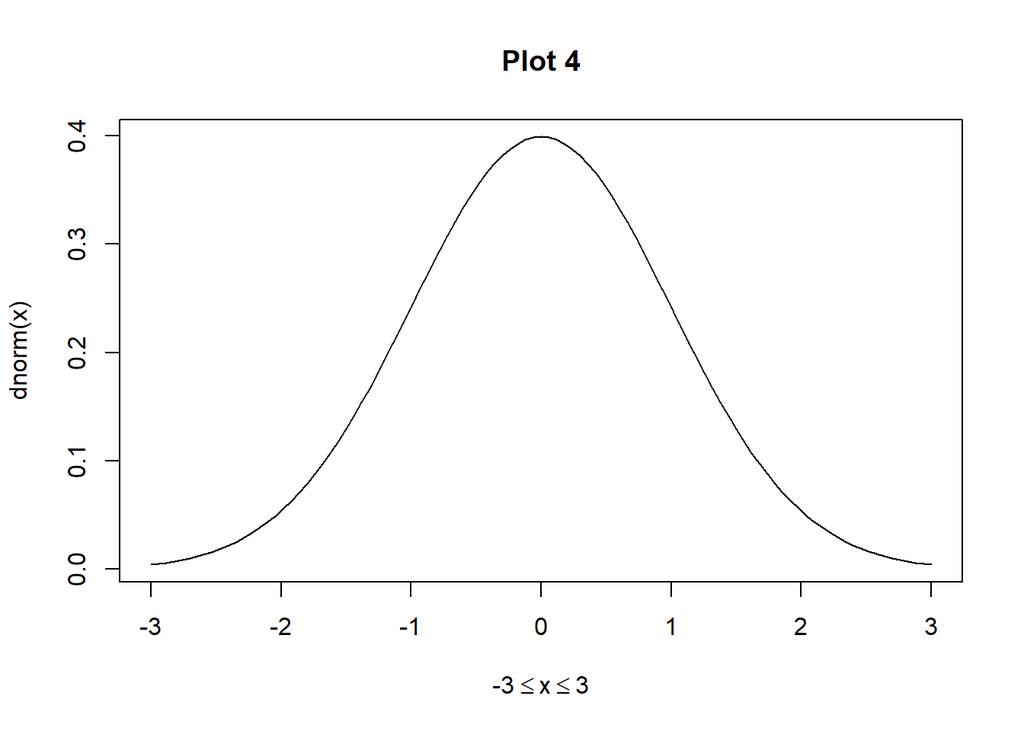

```r
curve(dnorm(x),
      xlim = c(-3,3),
      xlab = expression(paste("", "-3",
    phantom() <= phantom(), "x", "", phantom() <=
        phantom(), "3", "")),
      main = "Plot 4"
)
```

This teaches us how to make a valid R expression using the function `phantom()` and from now on we can go directly to the code or if you like and know $\LaTeX$ use the above package.

The technique is to make a valid expression for `<=` with `phantom() <= phantom()`

The function will leave a gap the size of the character you put in as an argument – example:

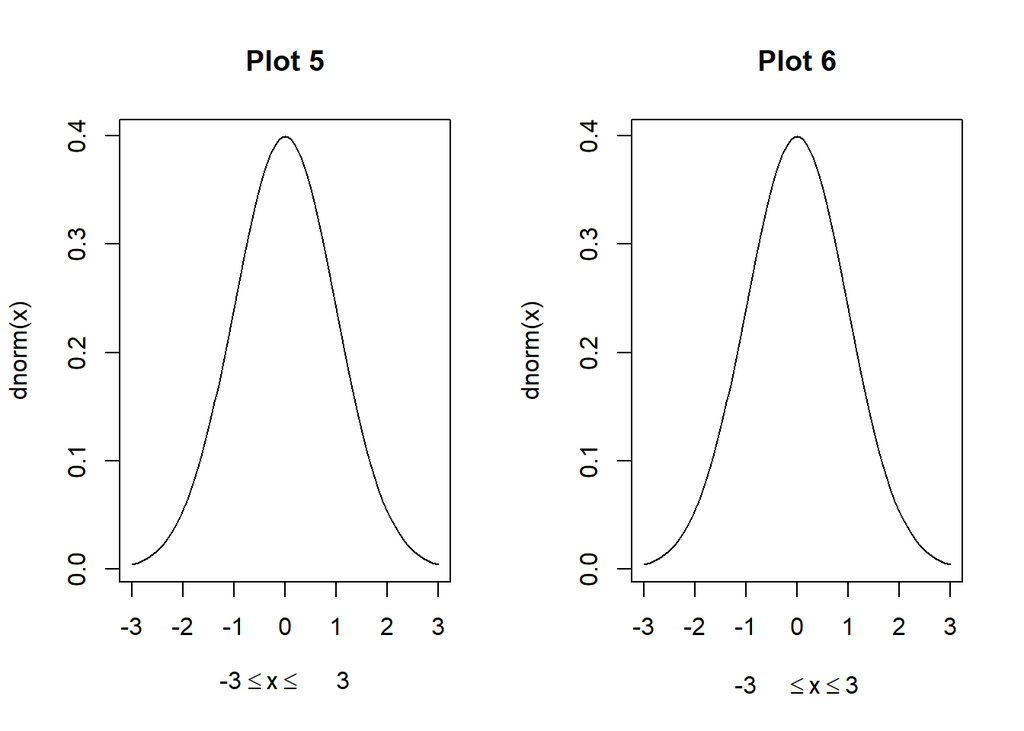

```r
layout(matrix(1:2,nr=1))

curve(dnorm(x),
      xlim = c(-3,3),
      xlab = expression(paste("", "-3",
    phantom() <= phantom(), "x", "", phantom() <=
        phantom(xyz), "3", "")),
      main = "Plot 5"
)

curve(dnorm(x),
      xlim = c(-3,3),
      xlab = expression(paste("", "-3",
    phantom(23) <= phantom(), "x", "", phantom() <=
        phantom(), "3", "")),
      main = "Plot 6"
)
```